# chapter3

Tuomas Junna

2023-11-16

# Assignment 3: Logistic regression

This is the third assignment on the IODS course. It uses a dataset from http://www.archive.ics.uci.edu/dataset/320/student+performance wrangled into it’s current form using the R scrip create_alc.R that can be found from the authors GitHub repository. The dataset is used to study the use of alcohol among students and includes background data of the study subjects as well as classification of students into two groups, high and low alcohol use. Alcohol use is considered high, when the students combined alcohol consumption over workweek and days off exceed an arbitrary number treshold of 2, as the questionnaire ranks alcohol use in both categories with numerical values from 1 to 5 corresponding to from very low to very high.

The purpose of this work is to study the relationships between high/low alcohol consumption and compare it to other variables in the dataset.

```r
#Libraries
library(tidyverse)
library(dplyr)

#Set working directory

setwd("C:/Users/tjunna/OneDrive - Valtori GTK/Desktop/R/IODS/IODS-project")

#Load alc

alc <- read.csv("data/alc.csv", sep = ",", header=TRUE)


alc <- alc
dim(alc)
```

```
## [1] 370  37
```

```r
names(alc)
```

```
##  [1] "school"      "sex"         "age"         "address"     "famsize"
##  [6] "Pstatus"     "Medu"        "Fedu"        "Mjob"        "Fjob"
## [11] "reason"      "guardian"    "traveltime"  "studytime"   "schoolsup"
## [16] "famsup"      "activities"  "nursery"     "higher"      "internet"
## [21] "romantic"    "famrel"      "freetime"    "goout"       "Dalc"
## [26] "Walc"        "health"      "failures"    "paid"        "absences"
## [31] "G1"          "G2"          "G3"          "alc_use"     "high_use"
## [36] "probability" "prediction"
```

```r
glimpse(alc)
```

```
## Rows: 370
## Columns: 37
## $ school      <chr> "GP", "GP", "GP", "GP", "GP", "GP", "GP", "GP", "GP", "GP"~
## $ sex         <chr> "F", "F", "F", "F", "F", "M", "M", "F", "M", "M", "F", "F"~
## $ age         <int> 18, 17, 15, 15, 16, 16, 16, 17, 15, 15, 15, 15, 15, 15, 15~
## $ address     <chr> "U", "U", "U", "U", "U", "U", "U", "U", "U", "U", "U", "U"~
## $ famsize     <chr> "GT3", "GT3", "LE3", "GT3", "GT3", "LE3", "LE3", "GT3", "L~
## $ Pstatus     <chr> "A", "T", "T", "T", "T", "T", "T", "A", "A", "T", "T", "T"~
## $ Medu        <int> 4, 1, 1, 4, 3, 4, 2, 4, 3, 3, 4, 2, 4, 4, 2, 4, 4, 3, 3, 4~
## $ Fedu        <int> 4, 1, 1, 2, 3, 3, 2, 4, 2, 4, 4, 1, 4, 3, 2, 4, 4, 3, 2, 3~
## $ Mjob        <chr> "at_home", "at_home", "at_home", "health", "other", "servi~
## $ Fjob        <chr> "teacher", "other", "other", "services", "other", "other",~
## $ reason      <chr> "course", "course", "other", "home", "home", "reputation",~
## $ guardian    <chr> "mother", "father", "mother", "mother", "father", "mother"~
## $ traveltime  <int> 2, 1, 1, 1, 1, 1, 1, 2, 1, 1, 1, 3, 1, 2, 1, 1, 1, 3, 1, 1~
```

[output cut: 24 more lines]

health - health - current health status (numeric: from 1 - very bad to 5 - very good) famrel - quality of family relationships (numeric: from 1 - very bad to 5 - excellent) romance - with a romantic relationship (binary: yes or no) absences -bsences - number of school absences (numeric: from 0 to 93)

We will compare these variables against the total mean consumption of alcohol (alc_use, that is the mean consumption over both work and off days) as well as to explore the defined frequent drinkers logical vector of high_use.

The classical hypothesis is that people consuming high amounts of alcohol had a horrible upbringing (famrel) in nasty household that made them develop an unhealthy outlook on romantic life (romance) so turn to drinking that would lead them to be absent from class and thus failing their courses while their health slowly deteriorates. It is what Charlie Sheen would call winning. As would I, for that matter. This is the least interesting and mind numbing approach to study like this I could figure out so naturally I will do it in the spirit of old Aki Kaurismäki films.

But let’s get to know our group of people first:

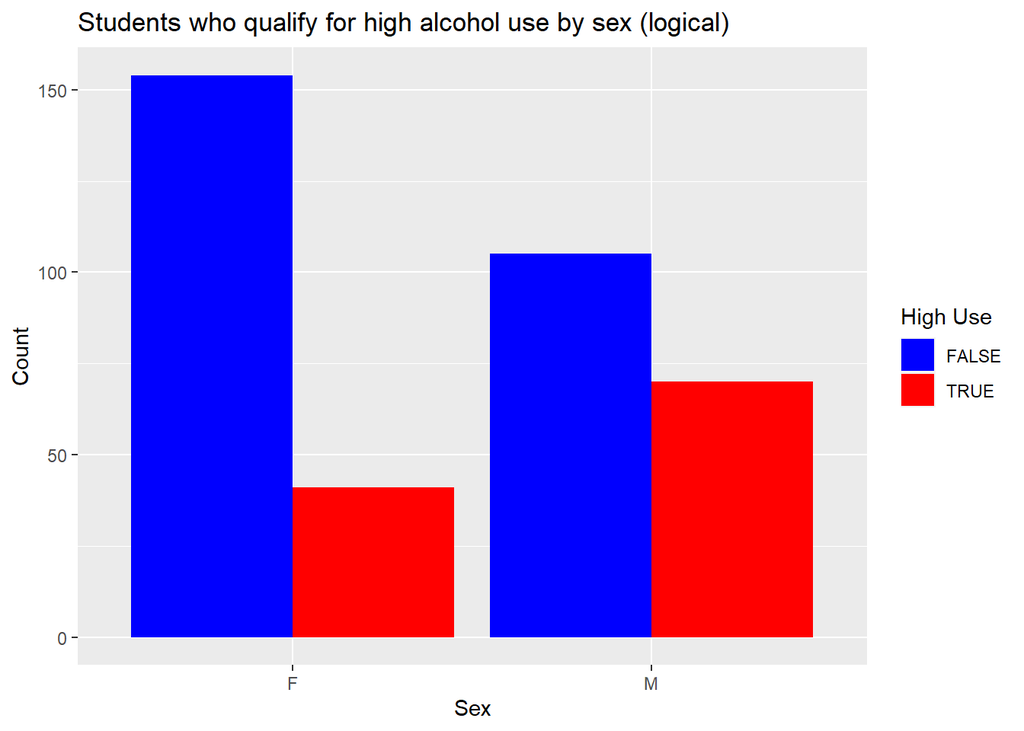

```
##
##   F   M
## 195 175
```

```
##
##  F  M
## 41 70
```

```
##
##     FALSE TRUE
##   F   154   41
##   M   105   70
```

We can see that out of female students, that frequent alcohol use is roughly twice as common among male students compared to females. Out of 195 female students, 41 qualify as gen-u-vine boozers whereas 70 out of male students make the cut. If we want a worse way of displaying the results, we can also use cross tabulation as on the last console printout.

As worse is cool, we will now check the same for chosen binary variables both using cross tabulation:

```r
# Create a cross table
cross_table2 <- table(alc$romantic, alc$high_use)

# Display the cross table
print(cross_table2)
```

```
##
##       FALSE TRUE
##   no    173   78
##   yes    86   33
```

```r
# Create a cross table
cross_table3 <- table(alc$famrel, alc$high_use)

# Display the cross table
print(cross_table3)
```

```
##
##     FALSE TRUE
##   1     6    2
##   2     9    9
##   3    39   25
##   4   128   52
##   5    77   23
```

The poor upbringing and issues on the homefront hypothesis is not looking too good either. If anything, apart from outliers, the distribution of different family relation qualities is very evenly matched to between the percentages of the demographic being light or heavy drinkers.

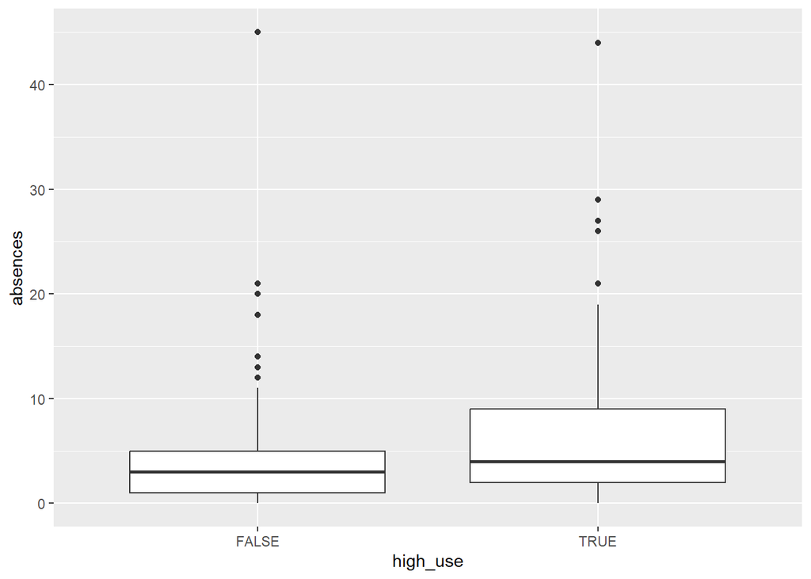

```r
# initialize a plot of high_use and absences
g1 <- ggplot(alc, aes(x = high_use, y = absences))

# define the plot as a box plot and draw it

g1 + geom_boxplot() + ylab("absences")
```

The boxplot of alcohol usage groups and their recorded absences from class demonstrate that on average, the people who indulge do tend to miss a class more often than the people who keep the deviljuice off their lips. It is notable, that the master absentee belongs to the light drinking group. I think I have succesfully identified the biggest pothead of the class.

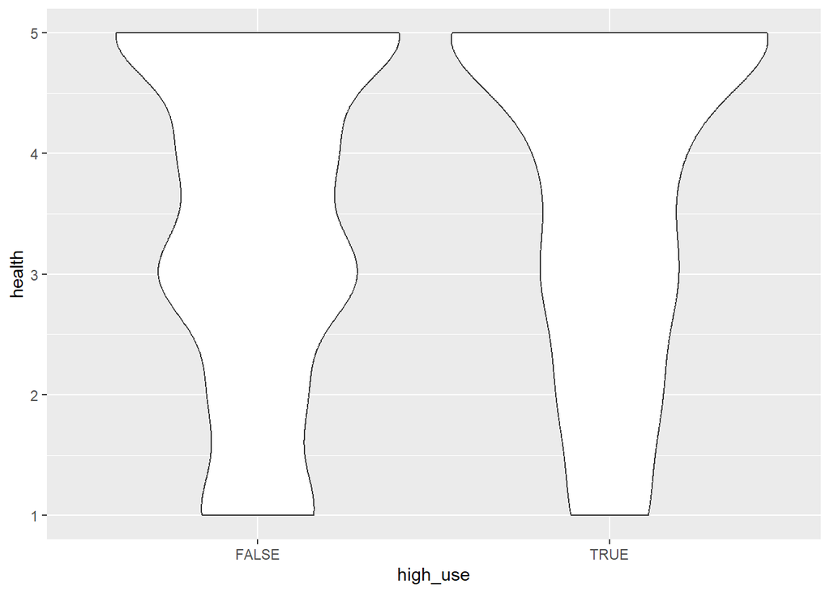

```r
# initialize a plot of high_use and absences
g2 <- ggplot(alc, aes(x = high_use, y = health))

# define the plot as a box plot and draw it

g2 + geom_violin() + ylab("health")
```

```r
# Create a cross table
cross_table4 <- table(alc$health, alc$high_use)

# Display the cross table
print(cross_table4)
```

```
##
##     FALSE TRUE
##   1    35   11
##   2    28   14
##   3    61   19
##   4    45   17
##   5    90   50
```

Well now we are getting somewhere! While the alcohol consumption obviously has not had any time to affect the health of these teenagers, it is very notable that the self reported health status of the heavier drinkers is top heavy, so they are feeling good!

So Mr. Kaurismäki hypothesis was not that great. We have thus proven that classic Finnish cinematography is pointless and that my chosen variables are not particularly good for studying the effects of alcohol consumption on teenagers. Most of them are basically healthy because they are teens, a huge number of them are in an early age relationship that will break down and truly introduce these kids to drinking later on and the people who drink might sleep in every now and then. Social/ health sciences in a nutshell…

But as this is just an exercise, let’s go on and use these variables as predictions in a logistic regression model:

```r
# Work with the exercise in this chunk, step-by-step. Fix the R code!
# alc is available

# find the model with glm()
m <- glm(high_use ~ health + absences + romantic + famrel, data = alc, family = "binomial")

# print out a summary of the model

summary(m)
```

```
##
## Call:
## glm(formula = high_use ~ health + absences + romantic + famrel,
##     family = "binomial", data = alc)
##
## Deviance Residuals:
##     Min       1Q   Median       3Q      Max
## -2.3327  -0.8276  -0.6956   1.1419   1.9755
##
## Coefficients:
##             Estimate Std. Error z value Pr(>|z|)
## (Intercept) -0.57420    0.58289  -0.985 0.324579
## health       0.16074    0.08733   1.841 0.065665 .
## absences     0.08819    0.02277   3.873 0.000108 ***
## romanticyes -0.34162    0.25965  -1.316 0.188273
## famrel      -0.30091    0.12772  -2.356 0.018468 *
## ---
## Signif. codes:  0 '***' 0.001 '**' 0.01 '*' 0.05 '.' 0.1 ' ' 1
##
## (Dispersion parameter for binomial family taken to be 1)
##
##     Null deviance: 452.04  on 369  degrees of freedom
## Residual deviance: 425.17  on 365  degrees of freedom
## AIC: 435.17
##
## Number of Fisher Scoring iterations: 4
```

```r
# print out the coefficients of the


# compute odds ratios (OR)
OR <- coef(m) %>% exp

# compute confidence intervals (CI)

CI <- confint(m) %>% exp
# print out the odds ratios with their confidence intervals
cbind(OR, CI)
```

```
##                    OR     2.5 %   97.5 %
## (Intercept) 0.5631533 0.1765400 1.749601
## health      1.1743814 0.9920800 1.398226
## absences    1.0921933 1.0466931 1.144796
## romanticyes 0.7106181 0.4227213 1.172751
## famrel      0.7401416 0.5750121 0.950398
```

```r
# Combine OR and CI into a data frame
results <- data.frame(OR = OR, CI)

# Print out the odds ratios with their confidence intervals
print(results)
```

```
##                    OR    X2.5..  X97.5..
## (Intercept) 0.5631533 0.1765400 1.749601
## health      1.1743814 0.9920800 1.398226
## absences    1.0921933 1.0466931 1.144796
## romanticyes 0.7106181 0.4227213 1.172751
## famrel      0.7401416 0.5750121 0.950398
```

First summary table is for the logistic regresseion data in the alc dataset. The response variable is high_use, aka, people who use alcohol more often and the predictor variables are health, absences, romantic, and famrel. The family parameter is set to “binomial” because we are dealing with binary outcomes.

Deviance residuals are a measure of how well the model fits the data. They are displayed as a five-number summary (minimum, 1st quartile, median, 3rd quartile, maximum). This case:

Minimum: -2.3327 1st Quartile: -0.8276 Median: -0.6956 3rd Quartile: 1.1419 Maximum: 1.9755

The goodness of fit of deviance residuals depends on various factors, and there isn’t a strict threshold for what can be considered “good” or “bad” deviance residuals. There are no apparent abnormal patterns in the residuals. The deviance residuals range from -2.3327 to 1.9755, indicating some variability. The five-number summary suggests that the residuals are not perfectly symmetrically distributed, and there might be some right-skewness. The model’s AIC is 435.17, and the residual deviance is 425.17, indicating a reasonably good fit.Deviance residuals should ideally have constant spread across all levels of predictors, indicating homoscedasticity. The heavily “top heavy” distribution of health observations could possibly affect this slightly, but the spread does not appear overly skewed.

The **coefficients** represent the log-odds of the response variable associated with each predictor, given the other predictors in the model are held constant. The p-values indicate the significance of each predictor. For example, **’absences` is highly significant** (p-value < 0.001), while **‘romantic’ is not significant** at conventional levels.

Below the summary, visible in the output table ares **odds ratios (OR)** and **confidence intervals (CI) for** the coefficients of a logistic regression model. The values are to be explored:

Odds Ratios (OR): Intercept: 0.5631533 health: 1.1743814 absences: 1.0921933 romanticyes: 0.7106181 famrel: 0.7401416 Confidence Intervals (CI): Intercept: [0.1765400, 1.749601] health: [0.9920800, 1.398226] absences: [1.0466931, 1.144796] romanticyes: [0.4227213, 1.172751] famrel: [0.5750121, 0.950398]

These can be interpreted as follows:

**Interpretation of Specific Coefficients:** The confidence interval for **health** includes 1, suggesting that the effect may **not be statistically significant**. The confidence interval for **Absences** does not include 1, indicating a **statistically significant effect**. The confidence interval for **romantic** includes 1, suggesting that the **effect may not be statistically significant**. The confidence interval for **famrel** does not include 1, indicating a **statistically significant effect**.

Findings are very interesting, as by first hand inspection of the family relations were completely separated from whether someone became a heavier drinker whereas the logistic model would suggest that better family relationships lead to decreased chance of heavy drinking. The health and romantic life categories were irrelevant as suspected and the clearly significant variable, amount of absences was statistically significant.

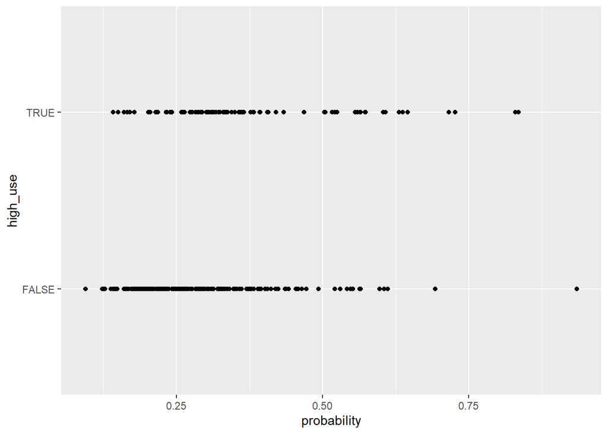

```r
modeller <- glm(high_use ~ absences, famrel, data = alc, family = "binomial")
alc <- mutate(alc, probability = predict(m, type = "response"))
alc <- mutate(alc, prediction = probability > 0.5)

# initialize a plot of 'high_use' versus 'probability' in 'alc'
gip <- ggplot(alc, aes(x = probability, y = high_use)) +
  geom_point()

# define the geom as points and draw the plot
gip
```

```r
# tabulate the target variable versus the predictions
table(high_use = alc$high_use, prediction = alc$prediction)
```

```
##         prediction
## high_use FALSE TRUE
##    FALSE   247   12
##    TRUE     89   22
```

The meaning of this is as follows:

What we can see, that according to confusion matrix, our model is far more likely to produce false negatives than false positives, meaning that there are factors beyond the grasp of our models that drive the bottle up peoples lips. In this sense, the model is apparently not a particularly useful tool for reasons discussed above.

```r
# define a loss function (mean prediction error)
loss_func <- function(class, prob) {
  n_wrong <- abs(class - prob) > 0.5
  mean(n_wrong)
}

# call loss_func to compute the average number of wrong predictions in the (training) data
loss_func(class = alc$high_use, prob = 0)
```

```
## [1] 0.3
```

```r
# compute the average number of wrong predictions in the (training) data

train_error <- loss_func(class = alc$high_use, prob = alc$probability)
print(train_error)
```

```
## [1] 0.272973
```

```r
# K-fold cross-validation
library(boot)
cv <- cv.glm(data = alc, cost = loss_func, glmfit = m, K = nrow(alc))

# average number of wrong predictions in the cross validation
cv$delta[1]
```

```
## [1] 0.2810811
```

```r
# Adjust the code: Perform 10-fold cross-validation
cv_10fold <- cv.glm(data = alc, cost = loss_func, glmfit = m, K = 10)

# Print out the mean prediction error for the testing data in 10-fold cross-validation
cv_10fold$delta[1]
```

```
## [1] 0.2783784
```